# Writing and Running Python Code in Jupyter Notebooks

(Hands on; 15 min)

R. Burke Squires

https://github.com/burkesquires

## Jupyter Notebook

[figure not shown]

## Cells

### Code Cells

In a **Code** cell you can write code ative to teh kernel you selected. A python kernel can run python code, an R kernel and can run R code.

An important and notable exception is the IPython kernel. Using the IPython kernel, which is the provied python kernel, one can run a number of different languages by using **cell magics** that we will see later. Cell magics enable the python kernel to run R code, bash shell code, etc.

When executing a code cell, if there is any output it is displayed below the executed cell as shown below.

You will also notice brackets next to the code cell. When a code cell is executed an integer based counter increases in value between the brackets. If a value is present before eecution, executing the cell again will replace the existing value. Thus the values betwene the brackets keep a loose history of the order in which code cells were executed.

```python
print("Hello world")
```

[output not shown]

```python
#%matplotlib inline # used to be needed to show plot in the notebook but no longer needed
import matplotlib.pyplot as plt
import numpy as np
```

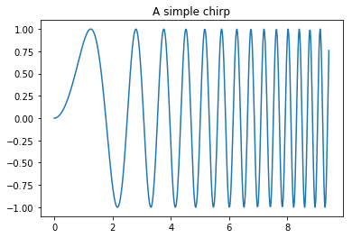

```python
x = np.linspace(0, 3*np.pi, 500)
plt.plot(x, np.sin(x**2))
plt.title('A simple chirp');
```

### Visualizations / Media

In addition to displaying visualize results of analysis, the Jupyter Notebook can also display a number of other media types including images, whole webpages, audio and video contents.

We will see some examples with Markdown in a moment.

## Getting help

```
?          Introduction and overview of IPython’s features
%quickref  Quick reference.
help       Python’s own help system.
object?    Details about ‘object’, use ‘object??’ for extra details.
```

```python
?
```

```python
import os
```

```python
os?
```

```python
help(os)
```

### Display variables with `%whos`

Since the Jupyter notebook doesn't have a separate window to display the variables that have been generated, we can use the commands %who, %who_ls, or %whos to show a complete list of imported modules, functions, variables, and other outputs (eg. figures). The command %who lists the variable names in row format, %who_ls lists the variable names in column format, and %whos is the most comprehensive, displaying variable name, type, and data/info. Remember this tool throughout the following tutorials if you need to check whether a module or function was already imported, a variable created, etc.

```python
%whos
```